# Données Ouvertes - Base de données sur les inégalités dans le monde

# 5 Données Erasmus

On se propose de lier nos données sur un jeu de données accessibles sur le net, sur le site du https:/fr.statista.com/, qui répertorie pour l’année 2016, sur quelques pays européens, le nombre d’étudiants ayant effectué un échange Erasmus, il se compose de deux fichiers *Csv*, l’un avec une liste de pays et le nombre de leurs étudiants envoyés à l’étranger, le second avec une liste de pays et leurs étudiants reçus en échange.

| Pays | NbrEtuEnv | NbrEtuRec |
| --- | --- | --- |
| France | 39985 | 29558 |
| Allemagne | 39719 | 32871 |
| Espagne | 36842 | 42537 |
| Italie | 31051 | 21564 |
| Pologne | 16735 | 13101 |
| Royaume-Uni | 14801 | 30183 |
| Turquie | 14665 | NA |
| Pays-Bas | 12397 | 11445 |
| Belgique | 8652 | 10666 |
| République Tchèque | 8226 | NA |

[figure not shown]

# 6 Représentation des inégalités sur une carte

Avec R, il nous est possible d’utiliser le package *maps*, qui nous permet de représenter des indicateurs sur une carte représentant les pays.

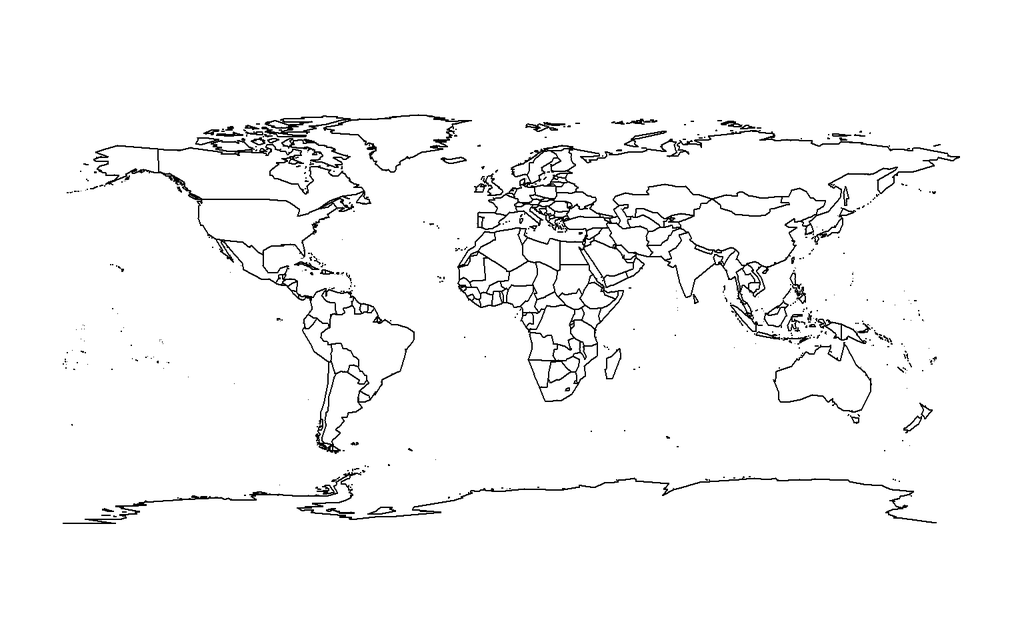

```r
Monde <- map(database = "world")
```

## 6.1 Produit National Brut

On peut alors colorer les pays en accord avec la valeur d’un indicateur, on se décide à récupérer les données sur le produit national brut, afin d’afficher sur une carte, par un jeu de couleurs, les différences entre pays, pour l’indicateur de produit national brut moyen par habitant. On prend l’année de référence 2015.

```
##    Min. 1st Qu.  Median    Mean 3rd Qu.    Max.
##   -4316    5220   14501   47868   32414 5184959
```

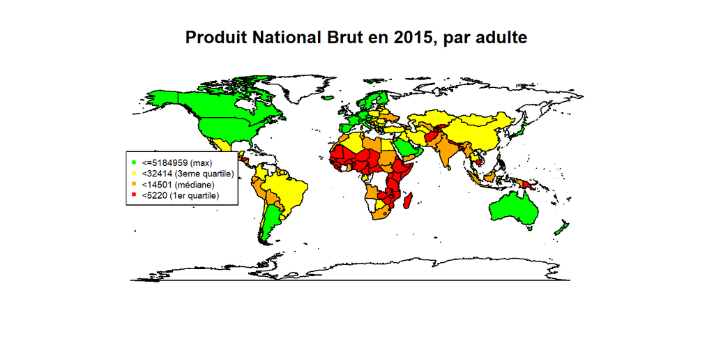

## 6.2 Représentation des revenus nationaux par pays sur une carte

On va donc se servir de cet outil, une fois encore, pour représenter les revenus moyens par adulte. Toujours sur l’année 2015.

```
##    Min. 1st Qu.  Median    Mean 3rd Qu.    Max.
##     254    4777   12187   42584   26408 4776164
```

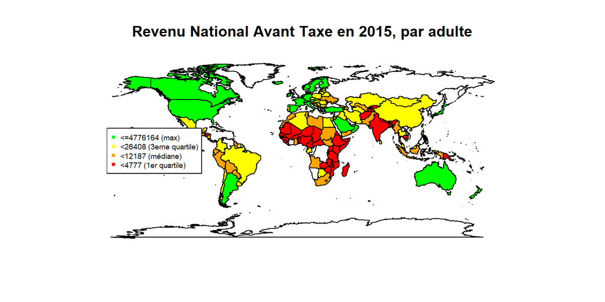

On a donc représenté les pays par rapport à leurs richesses propres, il serait intéressant de reporter maintenant les pays les plus inégalitaires. Mais comme nous l’avons vu lors de nos statistiques descriptives, le découpage en percentile des richesses mondiales, n’est présentes que dans certains pays.

# 7 Analyse temporelle de nos indicateurs

Pour finir, il nous semble judicieux de mettre à profit nos connaissances en séries temporelles pour essayer d’effectuer une analyse prédictive de certains indicateurs. On se propose de reprendre avec notre premier choix de graphe, la part de richesses des 1% et 10% plus riches. On démarre par des tests de stationnarités de *Dickey-Fuller* et *Kwiatkowski-Phillips-Schmidt-Shin*.

## 7.1 Part de richesses des 1% les plus aisés en France.

```r
unpourc <- download_wid(
    indicators = "shweal", # part des richesses personnelles
    areas = c("FR"), # En France
    perc = "p99p100" # Top 1% and top 10%
)
sc <- ts(unpourc$value, frequency = 12)#les 12 mois de l'année
adf.test(sc)
```

```
##
##  Augmented Dickey-Fuller Test
##
## data:  sc
## Dickey-Fuller = -1.0098, Lag order = 4, p-value = 0.9331
## alternative hypothesis: stationary
```

```r
kpss.test(sc)
```

```
##
##  KPSS Test for Level Stationarity
##
## data:  sc
## KPSS Level = 2.1228, Truncation lag parameter = 4, p-value = 0.01
```

```r
stl(sc,s.window = "periodic")
```

[output not shown]

[output cut: 66 more lines]

[output not shown]

On ne retient pas de composantes saisonnières. On cherche donc le modèle.

```r
auto.arima(sc)
```

```
## Series: sc
## ARIMA(1,1,2)
##
## Coefficients:
##           ar1     ma1     ma2
##       -0.9851  1.2828  0.3186
## s.e.   0.0275  0.1024  0.1003
##
## sigma^2 estimated as 0.0002553:  log likelihood=313.8
## AIC=-619.6   AICc=-619.24   BIC=-608.62
```

Il semblerait que ce soit un modèle ARIMA(1,1,2) qui soit retenu dans ce cas-là.

Et on va chercher à effectuer une estimation avec ce modèle sur les données.

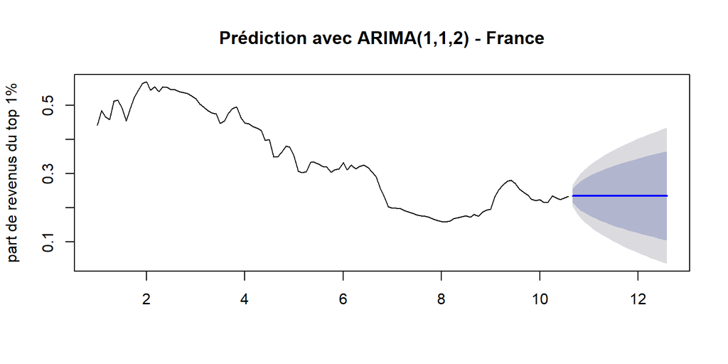

```r
plot(forecast(auto.arima(sc)), main = "Prédiction avec ARIMA(1,1,2) - France", ylab="part de revenus du top 1%")
```

La prédiction semble grossière, nous allons donc tenter une autre méthode.

Vu la simplicité du jeu de données, on va effectuer un lissage exponentiel simple en utilisant la fenêtre de Holt-Winters.

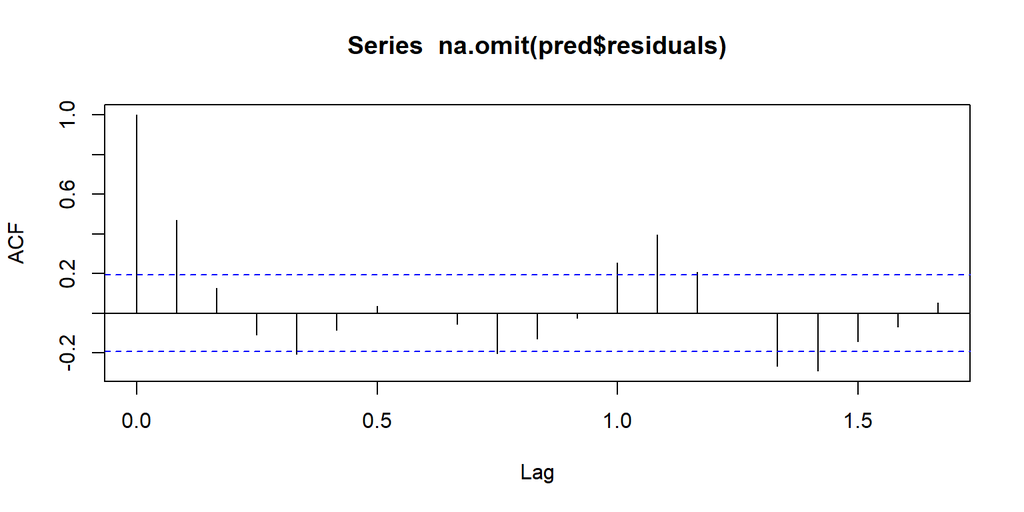

```r
lissage <- HoltWinters(sc)
pred <- forecast(lissage, h=20)
acf(na.omit(pred$residuals))
```

```r
shapiro.test(pred$residuals)
```

```
##
##  Shapiro-Wilk normality test
##
## data:  pred$residuals
## W = 0.98043, p-value = 0.1272
```

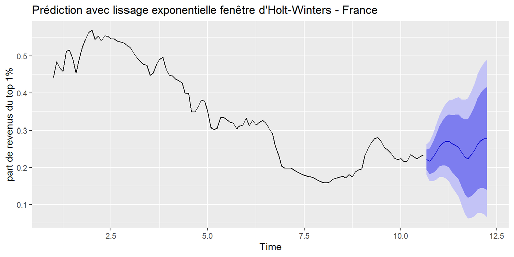

```r
tsppred <- c(sc, pred)
autoplot(pred, main = "Prédiction avec lissage exponentielle fenêtre d'Holt-Winters - France", ylab="part de revenus du top 1%")
```

On obtient alors quelque chose de plus intéressant, essayons finalement d’améliorer ce lissage exponentiel en passant par la fonction *ets()* qui évalue plusieurs lissages pour proposer le meilleur. De plus on obtient également la normalité de nos résidus.

```r
ets(sc)
```

```
## ETS(M,Ad,N)
##
## Call:
##  ets(y = sc)
##
##   Smoothing parameters:
##     alpha = 0.9999
##     beta  = 0.3161
##     phi   = 0.8
##
##   Initial states:
##     l = 0.3903
##     b = 0.0522
##
##   sigma:  0.0472
##
##       AIC      AICc       BIC
## -418.1364 -417.3658 -401.6149
```

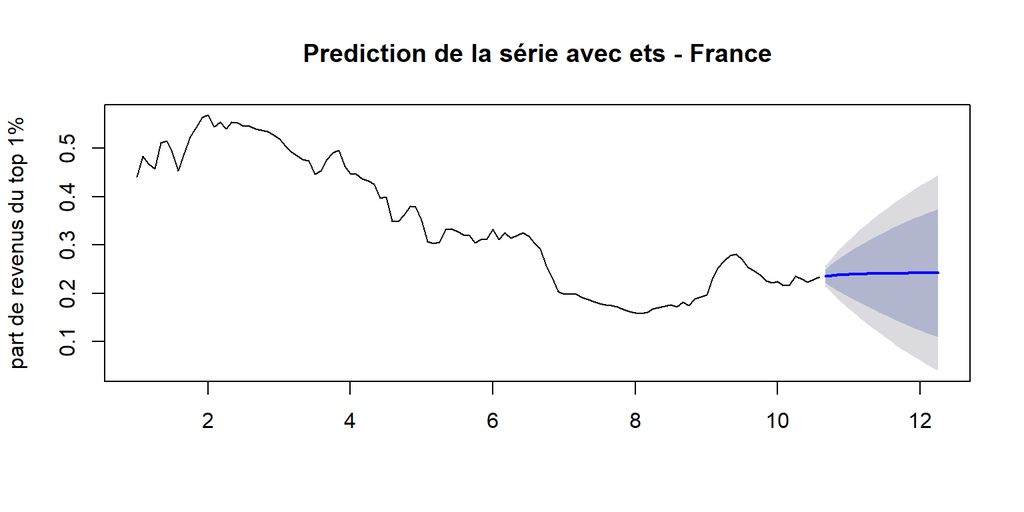

```r
plot(forecast(ets(sc),h=20,method ='ets'), main="Prediction de la série avec ets - France", ylab="part de revenus du top 1%")
```

On obtient des résultats similaires à ceux de ARIMA(1,1, 2), il semble donc que le lissage exponentiel simple avec la fenêtre d’Holt-Winters soit le plus satisfaisant

## 7.2 Part de richesses des 1O% les plus aisés en France.

Prenons maintenant la part de richesse des 10% les plus aisés en France.

```r
dixpourc <- download_wid(
    indicators = "shweal", # part des richesses personnelles
    areas = c("FR"), # En France
    perc = "p90p100" # Top 1% and top 10%
)
sc <- ts(dixpourc$value, frequency = 12)#les 12 mois de l'année
adf.test(sc)
```

```
##
##  Augmented Dickey-Fuller Test
##
## data:  sc
## Dickey-Fuller = -1.1149, Lag order = 4, p-value = 0.9166
## alternative hypothesis: stationary
```

```r
kpss.test(sc)
```

```
##
##  KPSS Test for Level Stationarity
##
## data:  sc
## KPSS Level = 2.2483, Truncation lag parameter = 4, p-value = 0.01
```

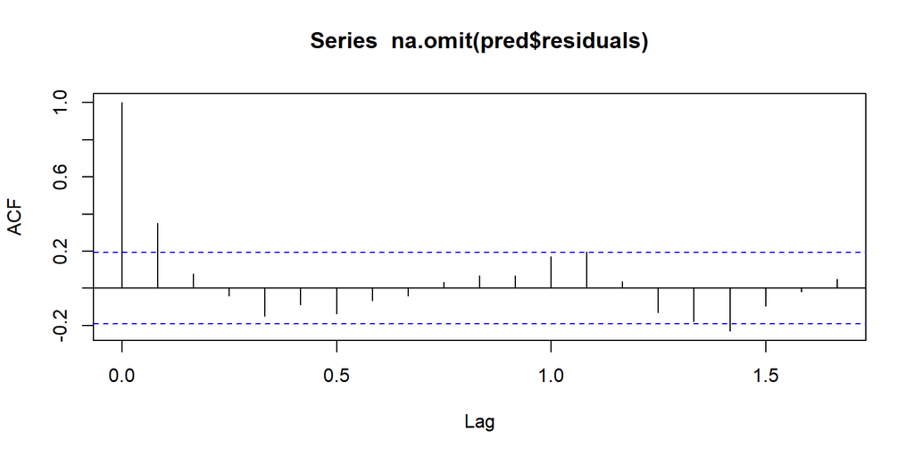

```r
lissage <- HoltWinters(sc)
pred <- forecast(lissage, h=20)
acf(na.omit(pred$residuals))
```

```r
shapiro.test(pred$residuals)
```

```
##
##  Shapiro-Wilk normality test
##
## data:  pred$residuals
## W = 0.9701, p-value = 0.01869
```

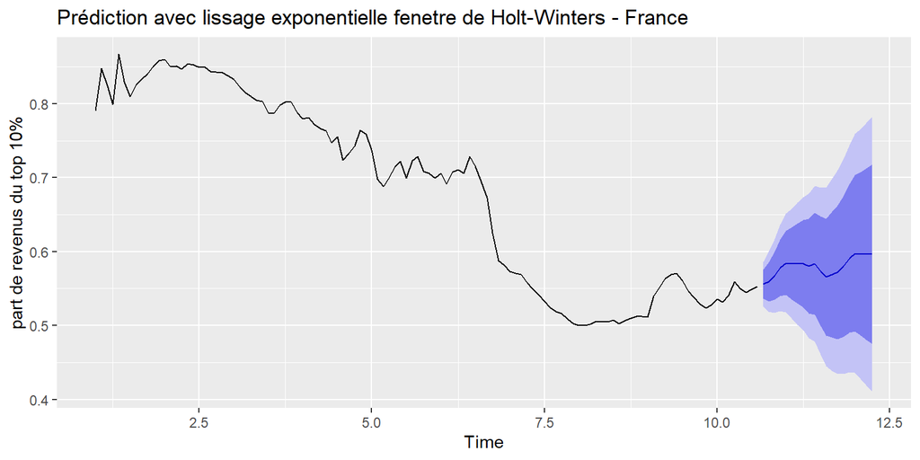

```r
tsppred <- c(sc, pred)
autoplot(pred, main = "Prédiction avec lissage exponentielle fenetre de Holt-Winters - France", ylab="part de revenus du top 10%")
```

Il serait maintenant intéressant de comparer avec d’autres pays.

## 7.3 Aux USA et en Chine.

```r
us <- download_wid(
    indicators = "shweal", # part des richesses personnelles
    areas = "US", # En France
    perc = "p90p100" # Top 1% and top 10%
)
sc <- ts(us$value, frequency = 12)#les 12 mois de l'année
adf.test(sc)
```

```
##
##  Augmented Dickey-Fuller Test
##
## data:  sc
## Dickey-Fuller = -1.4313, Lag order = 4, p-value = 0.8124
## alternative hypothesis: stationary
```

```r
kpss.test(sc)
```

```
##
##  KPSS Test for Level Stationarity
##
## data:  sc
## KPSS Level = 1.322, Truncation lag parameter = 4, p-value = 0.01
```

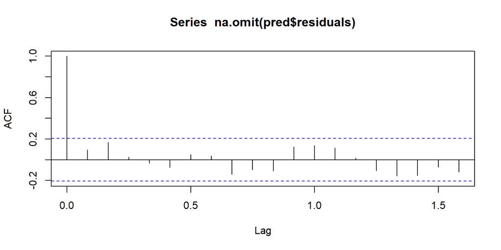

```
##
##  Shapiro-Wilk normality test
##
## data:  pred$residuals
## W = 0.99103, p-value = 0.8042
```

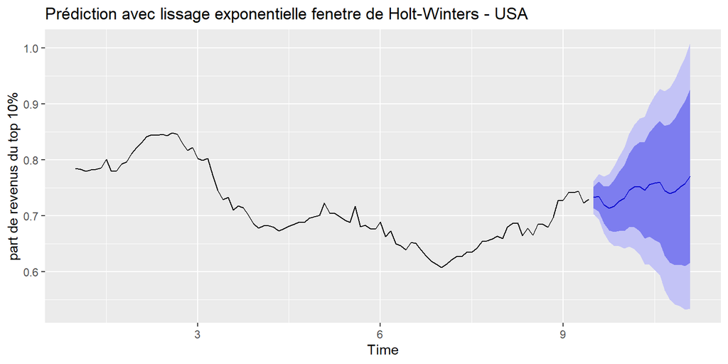

```r
cn <- download_wid(
    indicators = "shweal", # part des richesses personnelles
    areas = "CN", # En France
    perc = "p90p100" # Top 1% and top 10%
)
sc <- ts(cn$value, frequency = 12)#les 12 mois de l'année
adf.test(sc)
```

```
##
##  Augmented Dickey-Fuller Test
##
## data:  sc
## Dickey-Fuller = -1.4209, Lag order = 3, p-value = 0.7996
## alternative hypothesis: stationary
```

```r
kpss.test(sc)
```

```
##
##  KPSS Test for Level Stationarity
##
## data:  sc
## KPSS Level = 0.90146, Truncation lag parameter = 3, p-value = 0.01
```

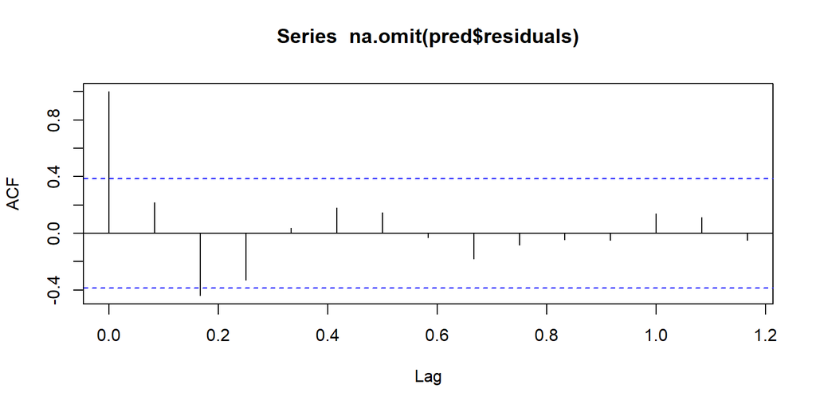

```
##
##  Shapiro-Wilk normality test
##
## data:  pred$residuals
## W = 0.95213, p-value = 0.2599
```

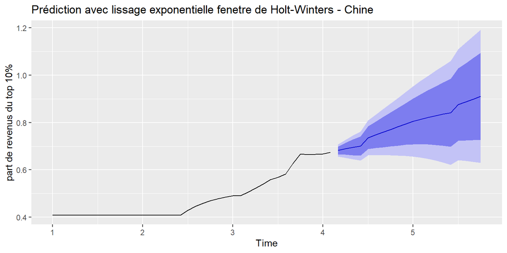

Il est intéressant de voir ces évolutions, cependant on se rend assez vite compte que notre méthode manque de rigueur, en effet on observe des évolutions temporelles d’un pourcentage des revenus, et l’on observe des prévisions en Chine où la barre des 1 serait dépassée, ce qui n’a pas de sens dans notre jeu de données, mais cela traduit tout de même la tendance à l’augmentation de l’écart entre les plus aisés et les plus pauvres. Mais aussi de la tendance bien plus rapide à arriver dans un pays comme la Chine par apport à la France ou aux États-Unis.

**Références**

https://wid.world/fr/ https://github.com/WIDworld/wid-r-tool http:/wid.World/percentiles https://www.youtube.com/playlist?list=PLnZgp6epRBbQzxFnQrcxg09kRt-PA66T_ https:/fr.statista.com/ https://www.lemonde.fr/blog/piketty/2020/01/14/apres-le-deni-climatique-le-deni-inegalitaire/ https://www.youtube.com/watch?v=J4iODLa9hYw https://www.oxfamfrance.org/rapports/ https://www.lucaschancel.info/ https://www.lemonde.fr/idees/article/2017/01/24/pour-un-revenu-universel-credible-et-audacieux_5068506_3232.html#Pe0dedYzOdG6TxK3.99 https://lgatto.github.io/IntroMachineLearningWithR/unsupervised-learning.html#pre-processing

Toufik Cheikh | Yahya Dakir | Hugo Lacauste | Giulio Martellucci  
Université de Bordeaux

18 Février 2020